# PS 8

Ying Cai & Mary Joyce

2018-11-26

**Front matter**

This submission is my work alone and complies with the 30531 integrity policy.

Add your initials to indicate your agreement: *YC & MJ*

```r
library(tidyverse)
library(dplyr)
library(ggmap)
library(ggpubr)
library(lubridate)
library(nycflights13)
library(cowplot)
Sys.setenv(TZ="America/Chicago")
con <- DBI::dbConnect(RMySQL::MySQL(),
                      path = ":memory:",
                      user = "ppha30531",
                      dbname = "Waze2",
                      port = 3306,
                      password = "Harris2018",
                      host = "uchicagowaze.cfykgneqoh8w.us-west-2.rds.amazonaws.com")
```

# 1 R4DS Chapter 16 (10 Points)

1. PS1 revisited: Compare dep_time, sched_dep_time and dep_delay. It should be the case that dep_time - sched_dep_time = dep_delay. Does this hold? Be sure to use the new material you learned in this chapter. Explain your findings.

If you only took the difference of dep_time - sched_dep_time then you do not get dep_delay for various reasons. If the scheduled departure time is on the hour (e.g. 6:00 AM, 7:00 AM), then the difference between the two values uses 100 minutes instead of 60 minutes at 6:00 AM. For one observation, a plane took off early at 5:55 AM instead of 6:00 AM, but the calculated delay was -45 mins. Also, it does not take into account departure times that happen on a different day.

You can use functions from the lubridate package to create new dep time and scheduled time. But when you take the difference, it shows the results in seconds. You would need to either divide by 60 to get it in minutes like dep_delay or use another function that converts it.

```r
clean_dttm <- function(year, month, day, time) {
  make_datetime(year, month, day, time %/% 100, time %% 100)
}
flights <- nycflights13::flights
(time_compare <- flights %>%
   filter(!is.na(dep_time), !is.na(sched_dep_time)) %>%
   mutate(
     dep_time_old       = dep_time,
     dep_time           = clean_dttm(year, month, day, dep_time),
     sched_dep_time_old = sched_dep_time,
     sched_dep_time     = make_datetime(year, month, day, hour, minute),
     dep_delay_clean    = dep_time - sched_dep_time,
     dep_delay_old      = dep_time_old - sched_dep_time_old
   ) %>%
    select(dep_time_old, dep_time, sched_dep_time_old, sched_dep_time, dep_delay, dep_delay_clean, dep_delay_old)
 )
```

```
## # A tibble: 328,521 x 7
##    dep_time_old dep_time            sched_dep_time_~ sched_dep_time
##           <int> <dttm>                         <int> <dttm>
##  1          517 2013-01-01 05:17:00              515 2013-01-01 05:15:00
##  2          533 2013-01-01 05:33:00              529 2013-01-01 05:29:00
##  3          542 2013-01-01 05:42:00              540 2013-01-01 05:40:00
##  4          544 2013-01-01 05:44:00              545 2013-01-01 05:45:00
##  5          554 2013-01-01 05:54:00              600 2013-01-01 06:00:00
##  6          554 2013-01-01 05:54:00              558 2013-01-01 05:58:00
##  7          555 2013-01-01 05:55:00              600 2013-01-01 06:00:00
##  8          557 2013-01-01 05:57:00              600 2013-01-01 06:00:00
##  9          557 2013-01-01 05:57:00              600 2013-01-01 06:00:00
## 10          558 2013-01-01 05:58:00              600 2013-01-01 06:00:00
## # ... with 328,511 more rows, and 3 more variables: dep_delay <dbl>,
## #   dep_delay_clean <time>, dep_delay_old <int>
```

2. Use the appropriate lubridate function to parse each of the following dates:

```r
d1 <- mdy("January 1, 2003")
d2 <- ymd("2013-Mar-07")
d3 <- dmy("06-Jun-2017")
d4 <- mdy(c("August 9 (2015)", "July 1 (2015)"))
d5 <- mdy("12/29/14")
```

3.Make a plot with two lines: the distribution of flight times within a day in the first half of the year and the distribution of flight times within a day over the second half of the year. How does the distribution change?

The distribution does not change significantly when comparing the first half of the year (January through June) to the second half of the year (July to December).

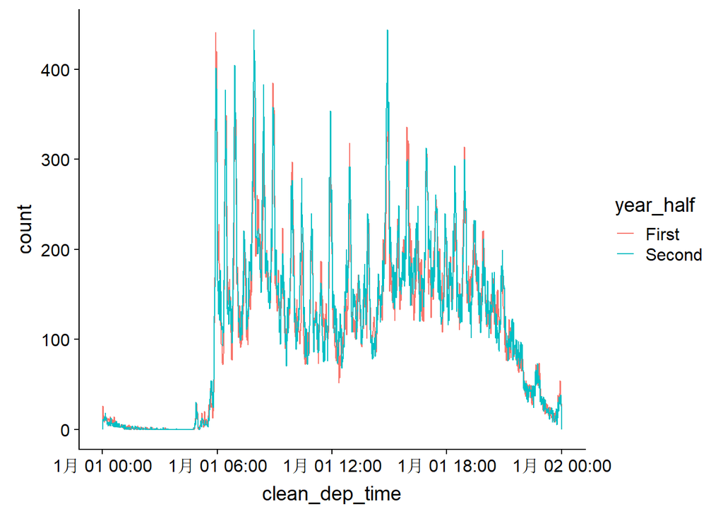

```r
flights_dep_time <-
  flights %>%
  filter(!is.na(dep_time), !is.na(sched_dep_time)) %>%
   mutate(dep_hour       = dep_time %/% 100,
          dep_min        = dep_time %% 100,
          clean_dep_time = as_datetime(dep_hour*60*60 + dep_min*60),
          year_half      = ifelse(month < 7, "First", "Second"))

flights_check <- flights %>%
  group_by(month) %>%
  summarise(count = n())

ggplot(flights_dep_time, aes(clean_dep_time)) + geom_freqpoly(aes(colour = year_half), binwidth = 60)
```

4. How does the average delay time change over the course of a day? Should you use dep_time or sched_dep_time? Why?

It appears as if the average delay increases over the course of a day, which makes sense as previously delayed flights impact subsequent flights the rest of the day. We plotted both dep_time and sched_dep_time, and it is clear that sched_dep_time should be used. As shown in Ch. 16 of R4DS, there is a bias in the actual departure times as humans often record times at “nice” intervals. Using the sched_dep_time will remove this bias from the data as shown in the graph.

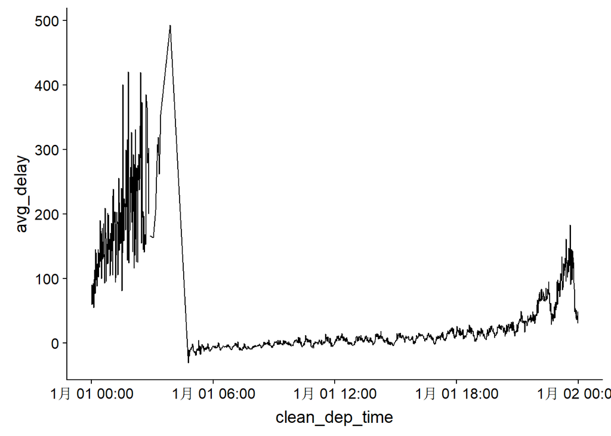

```r
# from Ch 16 of r4DS
flights_dt <- flights %>%
  filter(!is.na(dep_time), !is.na(arr_time)) %>%
  mutate(
    dep_time = clean_dttm(year, month, day, dep_time),
    arr_time = clean_dttm(year, month, day, arr_time),
    sched_dep_time = clean_dttm(year, month, day, sched_dep_time),
    sched_arr_time = clean_dttm(year, month, day, sched_arr_time)
  ) %>%
  select(origin, dest, ends_with("delay"), ends_with("time"))

flights_dep_delay <- flights_dt %>%
   mutate(dep_hour       = hour(dep_time),
          dep_min        = minute(dep_time),
          clean_dep_time = as_datetime(dep_hour*60*60 + dep_min*60)) %>%
 group_by(clean_dep_time) %>%
 summarise(
  avg_delay = mean(arr_delay, na.rm = TRUE),
  n = n())

ggplot(flights_dep_delay, aes(clean_dep_time, avg_delay)) + geom_line()
```

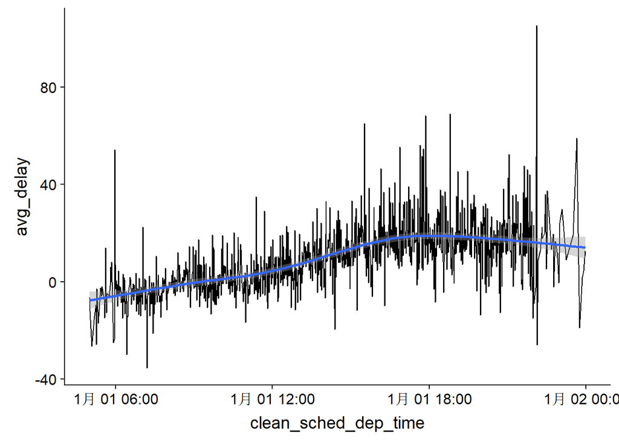

```r
flights_sched_delay <- flights_dt %>%
   mutate(sched_dep_hour        = hour(sched_dep_time),
          sched_dep_min         = minute(sched_dep_time),
          clean_sched_dep_time  = as_datetime(sched_dep_hour*60*60 +
                                                sched_dep_min*60)) %>%
  group_by(clean_sched_dep_time) %>%
  summarise(
  avg_delay = mean(arr_delay, na.rm = TRUE),
  n = n())

ggplot(flights_sched_delay, aes(clean_sched_dep_time, avg_delay)) + geom_line() + geom_smooth()
```

5. On what day of the week should you leave if you want to minimise the chance of a delay?

It appears that the day with a low average delay is Saturday. The average is actually negative which suggests that many flights on Saturday arrive early.

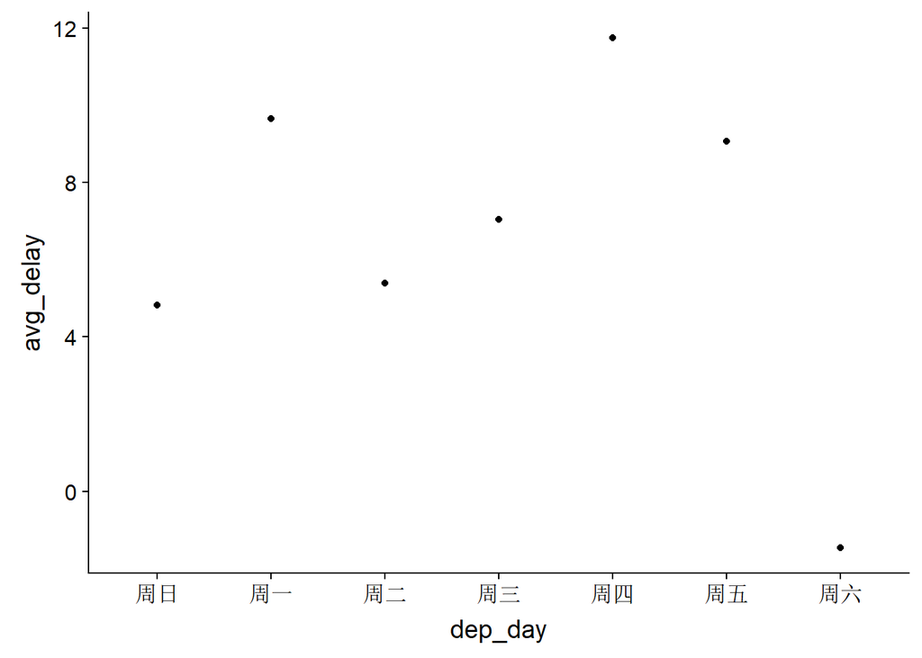

```r
flights_day <- flights_dt %>%
   mutate(dep_day = wday(sched_dep_time, label= TRUE)) %>%
 group_by(dep_day) %>%
 summarise(
  avg_delay = mean(arr_delay, na.rm = TRUE),
  n = n())

ggplot(flights_day, aes(x = dep_day, y = avg_delay)) + geom_point()
```

6. In what ways are the distributions diamonds$carat and flights$sched_dep_time similar? In what ways are they different? (Make a plot or two to support your claims.)

As mentioned in previous homeworks, a jeweler may round to a quarter carat, half carat, and one carat as that is what customers want. Therefore, there are areas in the graph where there are more observations at these cusps. Similarly in the flights data, when looking at the distribution over the course of an hour there is a larger portion of observations at 00 and 30 minute.

However, there shows a pattern of decreasing observations of diamonds as the carat size increases. There is no pattern in the scheduled flight times, which suggests that people’s preferences vary a lot so airlines provide many options across the course of a day.

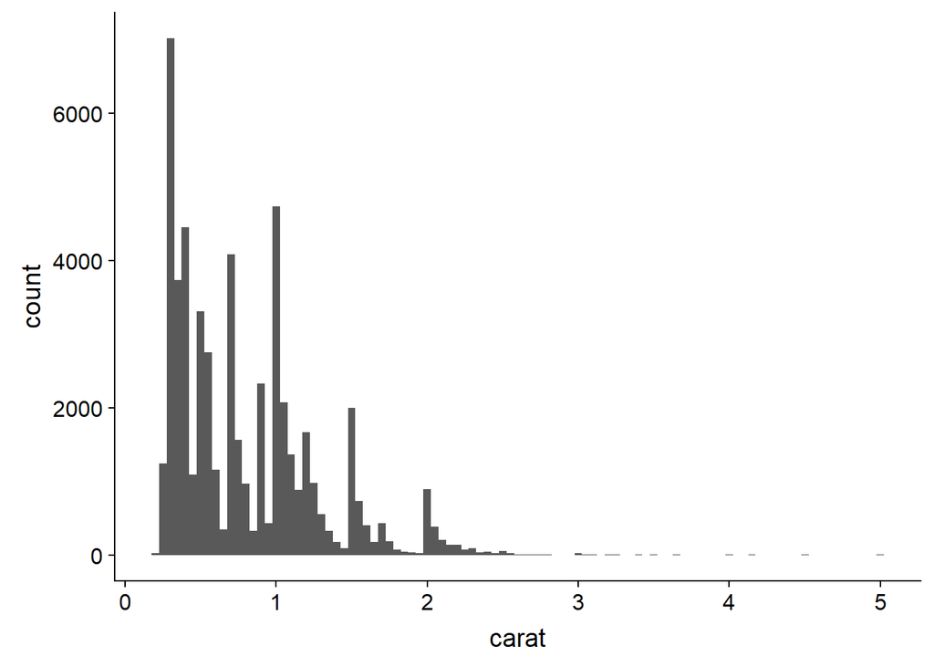

```r
ggplot(diamonds, aes(carat)) + geom_histogram(binwidth = 0.05)
```

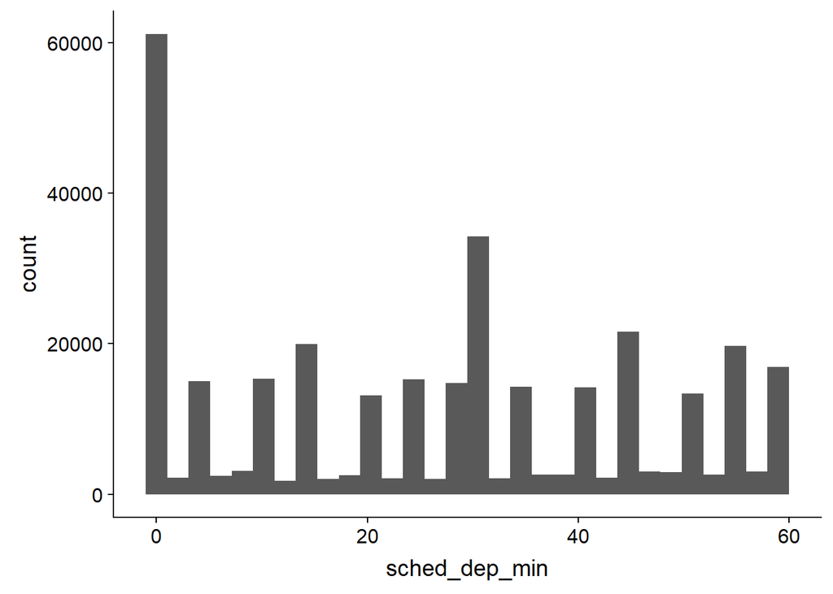

```r
flights_sched_min <- flights_dt %>%
  mutate(sched_dep_min = minute(sched_dep_time))

ggplot(flights_sched_min, aes(sched_dep_min)) + geom_histogram()
```

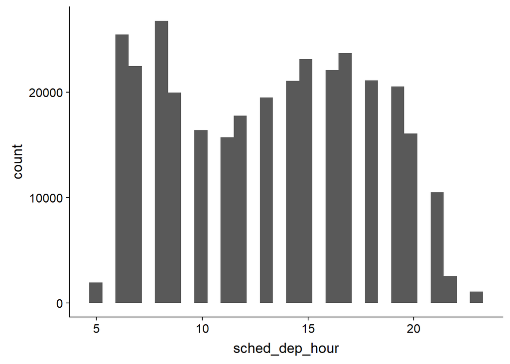

```r
flights_sched_hour <- flights_dt %>%
  mutate(sched_dep_hour = hour(sched_dep_time))

ggplot(flights_sched_hour, aes(sched_dep_hour)) + geom_histogram()
```

7. Create a vector of dates giving the first day of every month in 2015. Create a vector of dates giving the first day of every month in 2018.

```r
mdy("January 1, 2015") + month(0:11)
```

```
##  [1] "2015-01-01" "2015-01-02" "2015-01-03" "2015-01-04" "2015-01-05"
##  [6] "2015-01-06" "2015-01-07" "2015-01-08" "2015-01-09" "2015-01-10"
## [11] "2015-01-11" "2015-01-12"
```

```r
mdy("January 1, 2018") + month(0:11)
```

```
##  [1] "2018-01-01" "2018-01-02" "2018-01-03" "2018-01-04" "2018-01-05"
##  [6] "2018-01-06" "2018-01-07" "2018-01-08" "2018-01-09" "2018-01-10"
## [11] "2018-01-11" "2018-01-12"
```

8. Write a function that given your birthday (as a date), returns how old you are in years.

```r
count_age <- function(birthdate) {
  age <- today() - mdy(birthdate)
  as.duration(age)
}

#https://stackoverflow.com/questions/11007178/creating-a-prompt-answer-system-to-input-data-into-r
person_birth <- readline(prompt = "Enter birthday (month, day, year): ")
```

```
## Enter birthday (month, day, year):
```

```r
count_age(person_birth)
```

```
## [1] NA
```

9. If your home country is not the US, find the locale object for your home country and print it in your problem set. (If you are from the US, try the locale for finland). Print a date object which includes the day of the week, month, calendar day and year and uses the home country/finland locale. ##THIS SHOWS NO CHANGE##

```r
Sys.setenv(LANG = "es")
ymd(20181130)
```

```
## [1] "2018-11-30"
```

# 2 R4DS Chapter 21 (10 points)

1. Write for loops to:
2. Compute the mean of every column in mtcars.

```r
Sys.setenv(LANG = "en")
mean_cols <- vector("double", ncol(mtcars))
for (i in seq_along(mtcars)) {
  mean_cols[[i]] <- mean(mtcars[[i]])
}

mean_cols
```

```
##  [1]  20.090625   6.187500 230.721875 146.687500   3.596563   3.217250
##  [7]  17.848750   0.437500   0.406250   3.687500   2.812500
```

2. Compute the number of unique values in each column of mpg.

```r
col_distinct <- vector("integer", ncol(mpg))
for (i in seq_along(mpg)) {
  col_unique <- unique(mpg[[i]])
  col_distinct[[i]] <- length(col_unique)
}

col_distinct
```

```
##  [1] 15 38 35  2  4 10  3 21 27  5  7
```

3. Generate 10 random poissons (rpois) for each of lamda = -10, 0, 10, and 100. Think about the output, sequence, and body before you start writing the loop. ## Does this mean n = 10, and then lamda is what is listed? ##

```r
lamda <- c(-10, 0, 10, 100)
safe_rpois <- safely(rpois)

generate_rpois <- vector("list", length(lamda))
for (i in seq_along(lamda)) {
  generate_rpois[[i]] <- str(safe_rpois(10, lamda[[i]]))
}
```

```
## List of 2
##  $ result: int [1:10] NA NA NA NA NA NA NA NA NA NA
##  $ error : NULL
## List of 2
##  $ result: int [1:10] 0 0 0 0 0 0 0 0 0 0
##  $ error : NULL
## List of 2
##  $ result: int [1:10] 7 19 9 9 16 8 8 9 7 14
##  $ error : NULL
## List of 2
##  $ result: int [1:10] 122 106 89 96 108 102 79 86 113 98
##  $ error : NULL
```

2. Imagine you have a directory full of CSV files that you want to read in. You have their paths in a vector, files <- dir(“data/”, pattern = “\.csv$”, full.names = TRUE), and now want to read each one with read_csv(). Write the for loop that will load them into a single data frame.

```r
files <- dir("data/", pattern = "\\.csv$", full.names = TRUE)

unite_list <- vector("list", length(files))
for (i in seq_along(files)) {
  unite_list[[i]] <- read_csv(files[[i]])
}

unite_df <- dplyr::bind_rows(unite_list)
```

3. Write a function that prints the mean of each numeric column in a data frame, along with its name.

```r
means_df <- function(x) {
  num_cols <- Filter(is.numeric, x)
  mean_cols <- vector("list", ncol(num_cols))
  for (i in seq_along(num_cols)) {
    mean_cols[[i]] <- mean(num_cols[[i]])
    names(mean_cols)[[i]] <- names(num_cols)[[i]]
    cat(names(mean_cols)[[i]], ":", mean_cols[[i]],"\n")
  }
}

means_df(iris)
```

```
## Sepal.Length : 5.843333
## Sepal.Width : 3.057333
## Petal.Length : 3.758
## Petal.Width : 1.199333
```

```r
means_df(mtcars)
```

```
## mpg : 20.09062
## cyl : 6.1875
## disp : 230.7219
## hp : 146.6875
## drat : 3.596563
## wt : 3.21725
## qsec : 17.84875
## vs : 0.4375
## am : 0.40625
## gear : 3.6875
## carb : 2.8125
```

4. Write code that uses one of the map functions to:
5. Compute the mean of every column in mtcars.

```r
(means_cars <- mtcars %>% map_dbl(mean))
```

```
##        mpg        cyl       disp         hp       drat         wt
##  20.090625   6.187500 230.721875 146.687500   3.596563   3.217250
##       qsec         vs         am       gear       carb
##  17.848750   0.437500   0.406250   3.687500   2.812500
```

2. Compute the number of unique values in each column of mpg.

```r
(uniq_values <- mpg %>% map(n_distinct))
```

```
## $manufacturer
## [1] 15
##
## $model
## [1] 38
##
## $displ
## [1] 35
##
## $year
## [1] 2
##
## $cyl
## [1] 4
##
## $trans
## [1] 10
##
## $drv
## [1] 3
##
## $cty
## [1] 21
##
## $hwy
## [1] 27
##
## $fl
## [1] 5
##
## $class
## [1] 7
```

3. Generate 10 random poissons (rpois) for each of lamda = -10, 0, 10, and 100.

```r
lamda <- c(-10, 0, 10, 100)
safe_rpois <- safely(rpois)

(rpois_gen <- lamda %>% map( ~ safe_rpois(n = 10, .x)))
```

```
## [[1]]
## [[1]]$result
##  [1] NA NA NA NA NA NA NA NA NA NA
##
## [[1]]$error
## NULL
##
##
## [[2]]
## [[2]]$result
##  [1] 0 0 0 0 0 0 0 0 0 0
##
## [[2]]$error
## NULL
##
##
## [[3]]
## [[3]]$result
##  [1]  5  9 15  9 13  8  3  8 10  8
##
## [[3]]$error
## NULL
##
##
## [[4]]
## [[4]]$result
##  [1] 109  89 104 102  99 103 102  94  92 106
##
## [[4]]$error
## NULL
```

5. Imagine you have a directory full of CSV files that you want to read in. You have their paths in a vector, files <- dir(“data/”, pattern = “\.csv$”, full.names = TRUE), and now want to read each one with read_csv(). Write the map function that will load them into a single dataframe. (Hint: A special variant of map will make this very simple.)

```r
files <- dir("data/", pattern = "\\.csv$", full.names = TRUE)

unite_df <- files %>% map_dfr( ~ read_csv(.x))
```

6. In this question, we will investigate What happens when you use the map functions on vectors that aren’t lists. Use the following vector:

```r
five_squares <- (1:5)^2
```

1. Describe the output of using map on a list map(list(five_squares), rnorm). Explain why the output turns out this way.

The first argument in map is a list or atomic vector. Our list in this example is a list of 1 with five numbers, or [1:5]. When we use map and rnorm, the output provides a list of 1 with five numbers. Using map, this is equivalent to rnorm(1:5). This map is using the length of the list and passing it to the funciont, rnorm.

```r
output_a <- map(list(five_squares), rnorm)

rnorm(1:5)
```

```
## [1]  0.3567948  0.1608803  1.3663077 -0.7116729 -1.0542075
```

```r
(output_b <- map(five_squares, rnorm))
```

```
## [[1]]
## [1] 1.080569
##
## [[2]]
## [1]  0.6052647  2.1520182  1.0907014 -0.6433014
##
## [[3]]
## [1] -0.1001585  0.6700075 -0.5238985  0.7213677  0.4495526 -0.4224639
## [7]  1.7309200  0.3166741 -0.2231048
##
## [[4]]
##  [1]  0.55507954 -0.33275166  0.85738233 -0.25443137  0.09880845
##  [6]  0.67479611 -0.09130526  1.00242759  0.04952144 -0.09450124
## [11]  1.81355217  0.94420079  0.76850050  0.86971076  0.29288150
## [16]  0.76674984
##
## [[5]]
##  [1] -0.01284749 -0.85169845 -1.19175673 -1.30291199 -1.90773793
##  [6]  0.27198213  0.48027452  0.19155274 -0.95183854 -0.51623226
## [11]  0.45480264  0.36579319 -1.26641750  0.78478046  0.33508298
## [16]  0.35243996  1.74793809  1.37489813  0.27144473  0.19692952
## [21]  2.07263506  1.42830912 -0.86513803 -0.35313158 -1.03703116
```

3. What does map(five_squares, rnorm, n = 5) do? Why? In this example, the number of observations has been defined as n = 5, which will not change in the iteration. In this map example, the values in five_squares are being used to define the output’s mean. By default, mean = 0, but in this example the mean will be the value in five_squares in each iteration. For example, five_squares[2] = 4, so the function becomes rnorm(n = 5, mean = 4). Typically when you use the map function, the vector/list is used on the first argument of the function. But in this example, the first argument has been defined (n = 5) so it goes to the next argument, which is the mean.

```r
output_c <- map(five_squares, rnorm, n = 5)
```

# 3 R4DS Chapter 28 (10 points)

1. Create one plot on the fuel economy data with customised title, subtitle, caption, x, y, and colour labels.

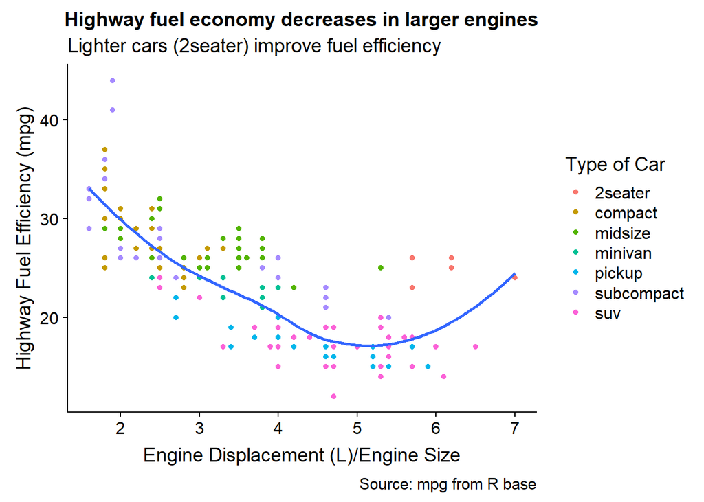

```r
ggplot(mpg, aes(displ, hwy)) +
  geom_point(aes(color = class)) +
  geom_smooth(se = FALSE) +
  labs(
    title = "Highway fuel economy decreases in larger engines",
    subtitle = "Lighter cars (2seater) improve fuel efficiency",
    caption = "Source: mpg from R base",
    x = "Engine Displacement (L)/Engine Size",
    y = "Highway Fuel Efficiency (mpg)",
    color = "Type of Car"
  )
```

2. Use geom_text() with infinite positions to place text at the four corners of the plot made previously.

[figure not shown]

```r
label_up_right <- tibble(
  displ = Inf,
  hwy = Inf,
  label = "High efficiency, \nlarge engine"
)

label_low_right <- tibble(
  displ = Inf,
  hwy = -Inf,
  label = "High efficiency, \nsmall engine"
)

label_low_left <- tibble(
  displ = -Inf,
  hwy = -Inf,
  label = "Low efficiency, \nsmall engine"
)

label_up_left <- tibble(
  displ = -Inf,
  hwy = Inf,
  label = "High efficiency, \nsmall engine"
)

ggplot(mpg, aes(displ, hwy)) +
  geom_point(aes(color = class)) +
  geom_smooth(se = FALSE) +
  labs(
    title = "Highway fuel economy decreases in larger engines",
    subtitle = "Lighter cars (2seater) improve fuel efficiency",
    caption = "Source: mpg from R base",
    x = "Engine Displacement (L)/Engine Size",
    y = "Highway Fuel Efficiency (mpg)",
    color = "Type of Car"
    ) +
  geom_text(
    aes(label = label),
    data = label_up_right,
    vjust = "top",
    hjust = "right"
    ) +
  geom_text(
    aes(label = label),
    data = label_low_right,
    vjust = "bottom",
    hjust = "right"
    ) +
  geom_text(
    aes(label = label),
    data = label_low_right,
    vjust = "bottom",
    hjust = "right"
    ) +
  geom_text(
    aes(label = label),
    data = label_low_left,
    vjust = "bottom",
    hjust = "left"
    ) +
  geom_text(
    aes(label = label),
    data = label_up_left,
    vjust = "top",
    hjust = "left"
    )
```

3. Read the documentation for annotate(). Provide an example showing how you can use it to add a text label to a plot without having to create a tibble?

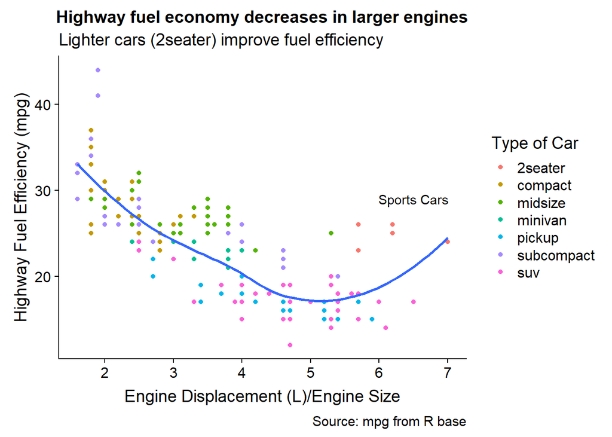

```r
ggplot(mpg, aes(displ, hwy)) +
  geom_point(aes(color = class)) +
  geom_smooth(se = FALSE) +
  labs(
    title = "Highway fuel economy decreases in larger engines",
    subtitle = "Lighter cars (2seater) improve fuel efficiency",
    caption = "Source: mpg from R base",
    x = "Engine Displacement (L)/Engine Size",
    y = "Highway Fuel Efficiency (mpg)",
    color = "Type of Car"
    ) +
  annotate("text", x = 6.5, y = 29, label = "Sports Cars")
```

4. Change the display of the presidential terms in Ch 28 by:
5. Improving the display of the y axis.
6. Placing breaks every 4 years (this is trickier than it seems!).

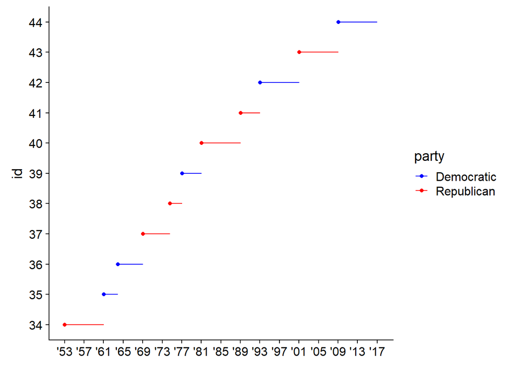

```r
presidential %>%
  mutate(id = 33 + row_number()) %>%
  ggplot(aes(start, id, colour = party)) +
    geom_point() +
    geom_segment(aes(xend = end, yend = id)) +
    scale_colour_manual(values = c(Republican = "red", Democratic = "blue")) +
  scale_x_date(NULL, date_breaks = "4 years", date_labels = "'%y") +
  scale_y_continuous(breaks = seq(33, 44, by = 1))
```

5. Improve the following plot.
1. Use override.aes to make the legend on the following plot easier to read and make each dot the same size.
2. Add plot labels with the name and year of 3 of the hurricanes. Be thoughtful in your selection.
3. Clarify the x and y axes labels.
4. Add a title that captures the message the graph puts across.

```r
storms
```

```
## # A tibble: 10,010 x 13
##    name   year month   day  hour   lat  long status category  wind pressure
##    <chr> <dbl> <dbl> <int> <dbl> <dbl> <dbl> <chr>  <ord>    <int>    <int>
##  1 Amy    1975     6    27     0  27.5 -79   tropi~ -1          25     1013
##  2 Amy    1975     6    27     6  28.5 -79   tropi~ -1          25     1013
##  3 Amy    1975     6    27    12  29.5 -79   tropi~ -1          25     1013
##  4 Amy    1975     6    27    18  30.5 -79   tropi~ -1          25     1013
##  5 Amy    1975     6    28     0  31.5 -78.8 tropi~ -1          25     1012
##  6 Amy    1975     6    28     6  32.4 -78.7 tropi~ -1          25     1012
##  7 Amy    1975     6    28    12  33.3 -78   tropi~ -1          25     1011
##  8 Amy    1975     6    28    18  34   -77   tropi~ -1          30     1006
##  9 Amy    1975     6    29     0  34.4 -75.8 tropi~ 0           35     1004
## 10 Amy    1975     6    29     6  34   -74.8 tropi~ 0           40     1002
## # ... with 10,000 more rows, and 2 more variables: ts_diameter <dbl>,
## #   hu_diameter <dbl>
```

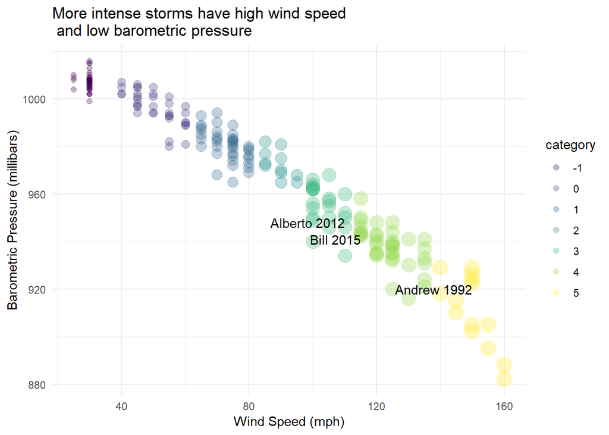

```r
category_storms <- storms %>%
  group_by(name) %>% summarize(wind = max(wind),
                               pressure = min(pressure),
                               category = max(category),
                               year = max(year))

hurricane_labels <-category_storms %>%
  group_by(category) %>%
  mutate(name_year = paste(name, year)) %>%
  filter(row_number(desc(category)) == 1 & wind >100)

category_storms %>% ggplot(aes(wind, pressure)) +
  geom_point(aes(size = category, colour = category), alpha = .3) +
  geom_text(aes(label = name_year), data = hurricane_labels, vjust = "top", hjust = "right") +
  theme_minimal() +
  labs(
    title = "More intense storms have high wind speed \n and low barometric pressure",
    x = "Wind Speed (mph)",
    y = "Barometric Pressure (millibars)"
    ) +
  guides(colour = guide_legend(override.aes = list(size = 2)))
```

# 4 Waze data start-up

1. New variable: Waze can track the frequency for accidents/jams/road block to happen in certain areas and construct a logical variable to detect whether an area is a risky area (based on current dataset and updated with new reports of alerts). This will be helpful for Waze users to be vigilant in advance When they go through areas where accidents/ jams / road blocks happen frequently thus it can help reduce the accidents.

Better way a to measure a current variable: Reliability: Currently, Reliability is based on reporter level and user response and it can be improved by also taking how many times other users reported the same accidents/jams/road blocks/weather hazards.

```r
waze <- tbl(con, "chiAlerts") %>% collect()
```

```r
waze <- read_csv("D:\\R\\dataset\\waze.csv")
```

2. It might cause some selection bias, Probably Waze users are people who care more about the traffic condition and sometimes the severity of accidents/ jams reported by them may be exaggerated.

# 5 Waze vision zero

[figure not shown]

```r
corr7 <-
  waze %>%
  filter(street == "N Western Ave") %>%
  filter(between(location_y, 41.895625, 41.934074))

map_corr7 <- get_googlemap(center = c(-87.6879, 41.9150), zoom = 14)
ggmap(map_corr7) + geom_count(corr7, mapping = aes(x = location_x, y = location_y), color = "red", alpha = 0.1)
```

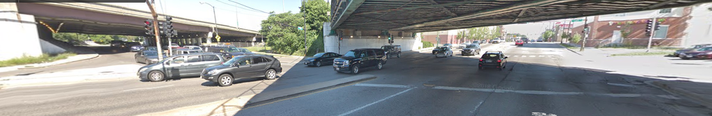

```r
knitr::include_graphics("D:\\R\\ps8-fall-2018-ps8-1-10\\intersection.png", dpi = NA)
```

# 6 Transit Oriented Development

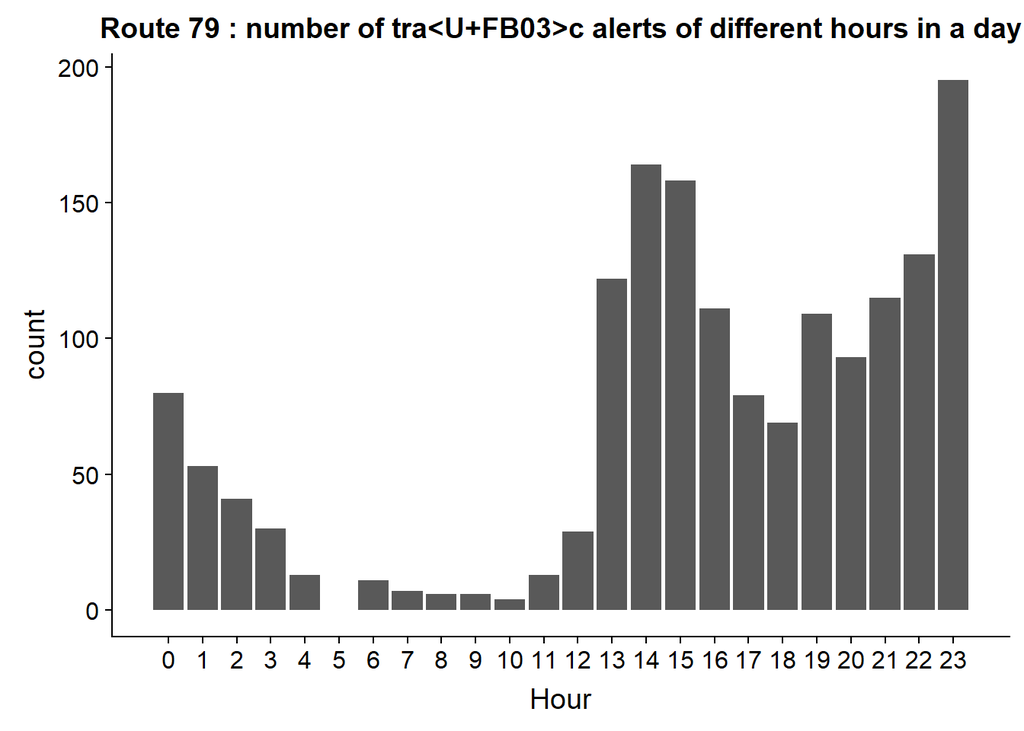

```r
route79 <- waze %>%
  filter(street == "W 79th St") %>%
  filter(between(location_x, -87.740831, -87.625302))

route79_trf <-
  route79 %>%
  filter(type == "JAM" | type == "ACCIDENT")

route66 <-
  waze %>%
  filter(street == "W Chicago Ave") %>%
  filter(between(location_x, -87.775115, -87.705422))

route66_trf <-  filter(route66, type == "JAM" | type == "ACCIDENT")

route79_trf <- mutate(route79_trf, hour = str_sub(route79_trf$scrape_dt, -8, -7)) %>% filter(!is.na(hour))
route66_trf <- mutate(route66_trf, hour = str_sub(route66_trf$scrape_dt, -8, -7))

p79 <-
  ggplot(route79_trf, aes(x = as.numeric(hour))) +
  geom_bar() +
  labs(x = "Hour", title = "Route 79 : number of traﬃc alerts of different hours in a day") +
  scale_x_continuous(breaks = c(0:23))
p79
```

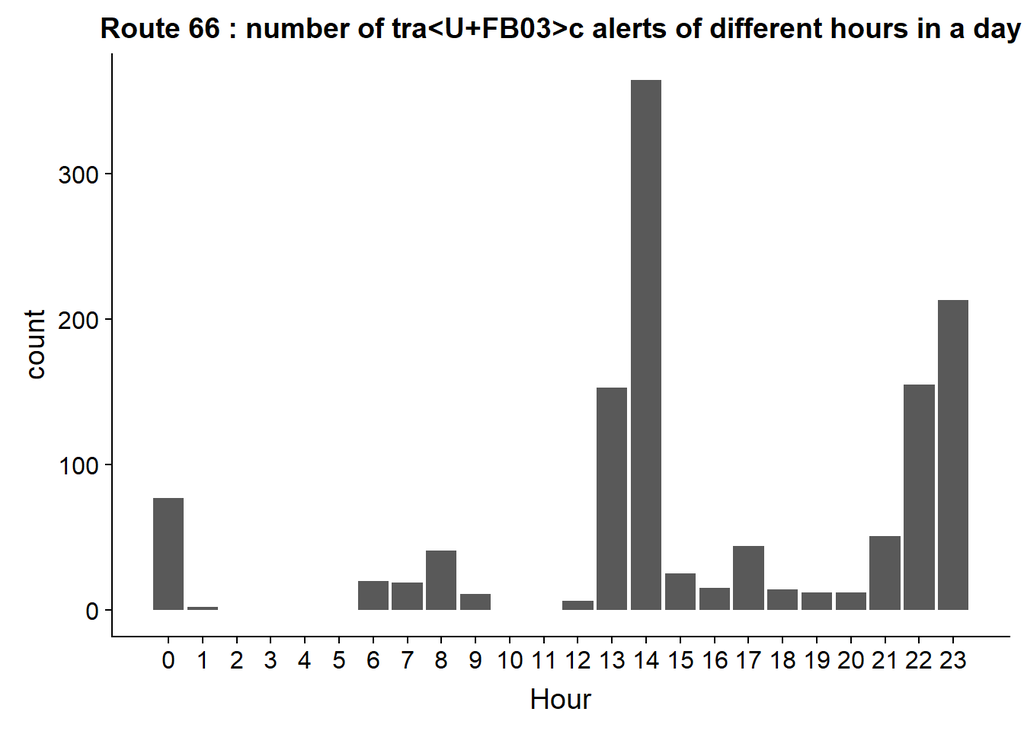

```r
p66 <-
  ggplot(route66_trf, aes(x = as.numeric(hour))) +
  geom_bar() +
  labs(x = "Hour", title = "Route 66 : number of traﬃc alerts of different hours in a day") +
  scale_x_continuous(breaks = c(0:23))
p66
```

2. I will choose route 78 to compare with route 79 because they are parallel in general and both connect the west part of chicgao to the lake side. For route 66, I will choose route 70 to compare with it because they are parallel in general and are close to each other.  
   After compare these two pairs, we can find that the hours during which alerts are most common have a rather similar pattern.

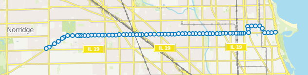

```r
#compare route 78 and 79
knitr::include_graphics("D:\\R\\ps8-fall-2018-ps8-1-10\\route 78.png", dpi = NA)
```

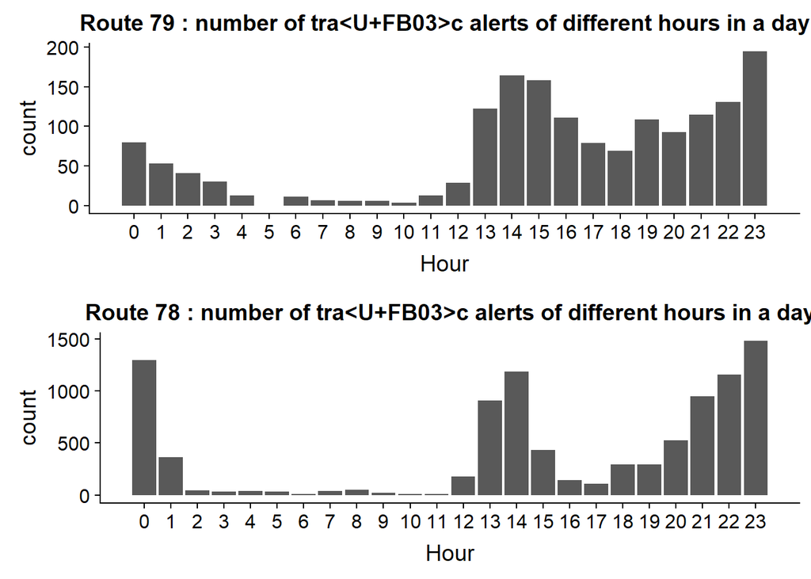

```r
route78 <-
  waze %>%
  filter(street == "W Montrose Ave") %>%
  filter(between(location_x, -87.793854, -87.665834))

route78_trf <- filter(route78, type == "JAM" | type == "ACCIDENT")

route78_trf <- mutate(route78_trf, hour = str_sub(route78_trf$scrape_dt, -8, -7))

p78 <-
  ggplot(route78_trf, aes(x = as.numeric(hour))) +
  geom_bar() +
  labs(x = "Hour", title = "Route 78 : number of traﬃc alerts of different hours in a day") +
  scale_x_continuous(breaks = c(0:23))

plot_grid(p79, p78, nrow = 2)
```

[figure not shown]

```r
#compare route 70 and 66
knitr::include_graphics("D:\\R\\ps8-fall-2018-ps8-1-10\\route 70.png", dpi = NA)
```

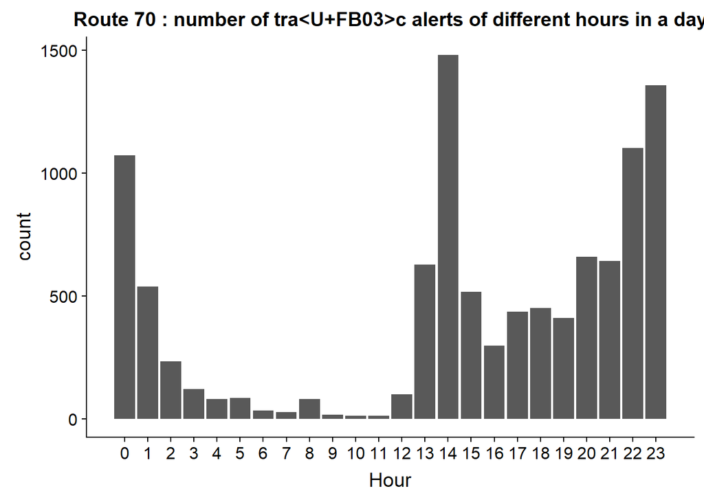

```r
route70 <-
  waze %>%
  filter(street == "W Division St") %>%
  filter(between(location_x, -87.774816, -87.631927))

route70_trf <- filter(route70, type == "JAM" | type == "ACCIDENT")
route70_trf <- mutate(route70_trf, hour = str_sub(route70_trf$scrape_dt, -8, -7))

p70 <-
  ggplot(route70_trf, aes(x = as.numeric(hour))) +
  geom_bar() +
  labs(x = "Hour", title = "Route 70 : number of traﬃc alerts of different hours in a day") +
  scale_x_continuous(breaks = c(0:23))
p70
```

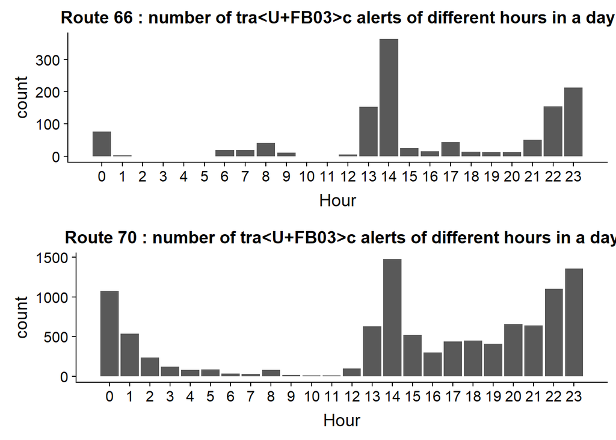

```r
plot_grid(p66, p70, nrow = 2)
```

3. Looking beyond traﬃc, alerts of weather hazard are very common in this area, which will also slow down the 66/79. The City can improve the condition of roads to increase their resistance to bad weather and provide better weather hazard alerts in advance to help address this issue.

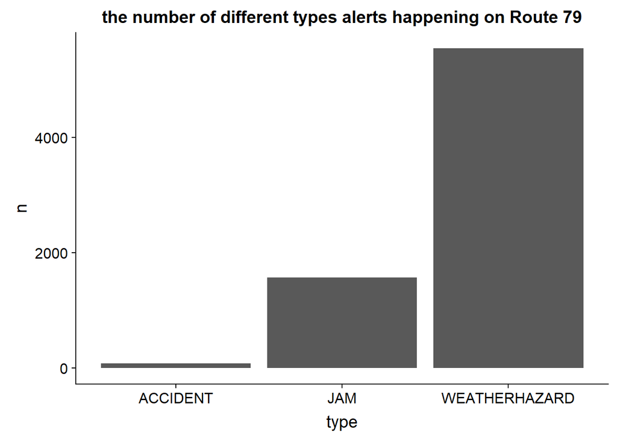

```r
route79 %>%
  group_by(type) %>%
  summarise(n = n()) %>%
  ggplot(aes(x = type, y = n)) + geom_col() + labs(title = "the number of different types alerts happening on Route 79")
```

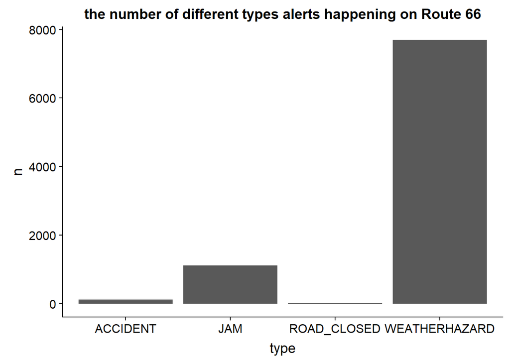

```r
route66 %>%
  group_by(type) %>%
  summarise(n = n()) %>%
  ggplot(aes(x = type, y = n)) + geom_col() + labs(title = "the number of different types alerts happening on Route 66")
```

# 7 Waze single event (15 point)

1. Revisit the event which caused c5a73cc6-5242-3172-be5a-cf8990d70cb2.
1. Define a bounding box around the cause of the event.

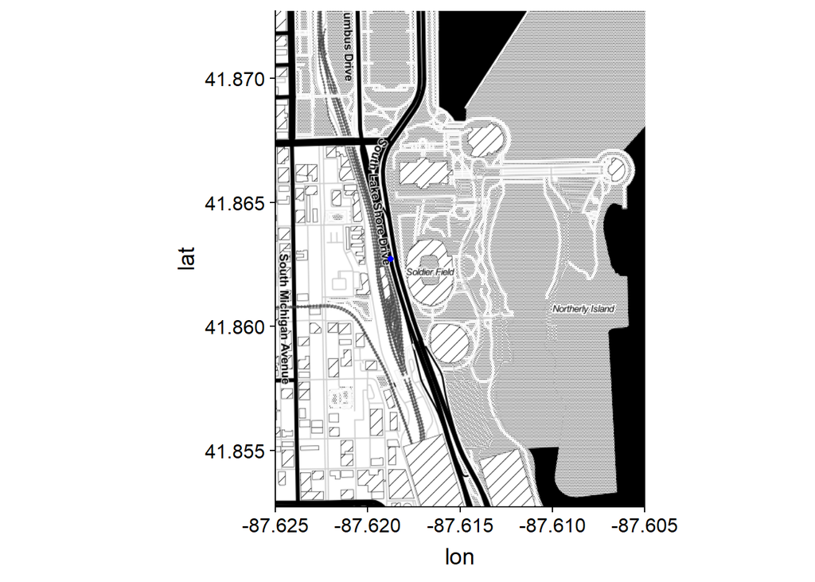

```r
single_incident <- waze %>%
  filter(uuid == "c5a73cc6-5242-3172-be5a-cf8990d70cb2")

map_border <- c(left = -87.625, bottom = 41.85272, right = -87.605, top = 41.87272)

map_incident <- get_stamenmap(map_border, zoom = 15, maptype = "toner-2011")
ggmap(map_incident) + geom_point(single_incident, mapping = aes(x = location_x, y = location_y), colour = "blue")
```

2. What causes all these jams? Some googling might help. On December 24, 2017, the Chicago Bears had their last football game. The weather history also showed almost 3 inches of snow that day, which likely led to the traffic jam.
3. Plot the number of jams 6AM-6PM CST. Why are there two humps?

```r
(jams_bbox <- waze %>%
  filter(location_x <= -87.605 &
           location_x >= -87.625 &
           location_y <= 41.87272 &
           location_y >= 41.85272) %>%
  mutate(time_frame    = ymd_hms(scrape_dt))%>%
  filter(time_frame >= ymd_hms("2017-12-24 06:00:00") &
         time_frame <= ymd_hms("2017-12-24 18:00:00") &
               type == "JAM")
)
```

```
## # A tibble: 112 x 18
##    country nTHumbsUp city  reportRating confidence reliability type  uuid
##    <chr>       <int> <chr>        <int>      <int>       <int> <chr> <chr>
##  1 US              0 Chic~            1          0           5 JAM   9299~
##  2 US              0 Chic~            1          0           5 JAM   9299~
##  3 US              0 Chic~            1          0           5 JAM   9299~
##  4 US              0 Chic~            1          0           5 JAM   9299~
##  5 US              0 Chic~            1          0           5 JAM   9299~
##  6 US              0 Chic~            1          0           5 JAM   9299~
##  7 US              0 Chic~            2          0           5 JAM   e97e~
##  8 US              0 Chic~            2          0           5 JAM   e97e~
##  9 US              0 Chic~            2          0           5 JAM   e97e~
## 10 US              0 Chic~            2          0           5 JAM   e97e~
## # ... with 102 more rows, and 10 more variables: roadType <int>,
## #   magvar <int>, subtype <chr>, street <chr>, location_x <dbl>,
## #   location_y <dbl>, pubMillis <dbl>, reportDescription <chr>,
## #   scrape_dt <dttm>, time_frame <dttm>
```

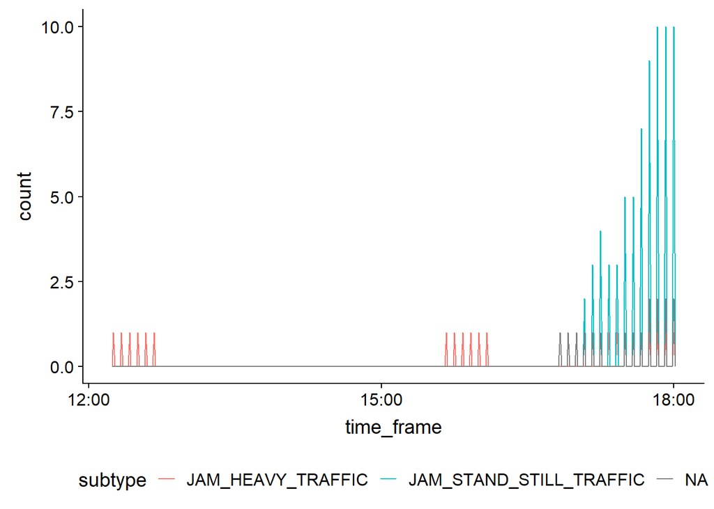

```r
ggplot(jams_bbox, aes(time_frame)) +
  geom_freqpoly(aes(colour = subtype), binwidth = 50) +
  theme(legend.position = "bottom")
```

4. Place one vertical line at each hump.

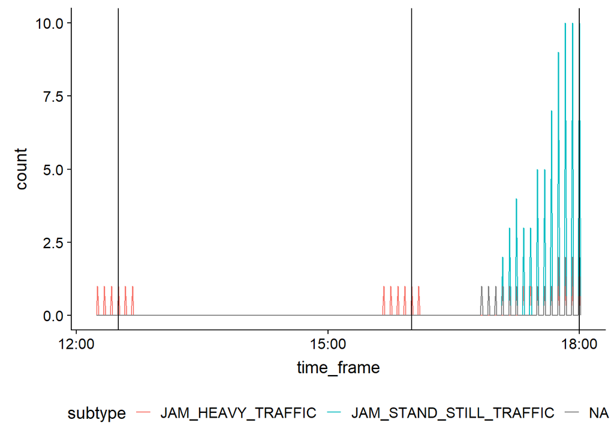

```r
ggplot(jams_bbox, aes(time_frame)) +
  geom_freqpoly(aes(colour = subtype), binwidth = 50) +
  theme(legend.position = "bottom") +
  geom_vline(xintercept = ymd_hms("2017-12-24 12:30:00")) +
  geom_vline(xintercept = ymd_hms("2017-12-24 16:00:00")) +
  geom_vline(xintercept = ymd_hms("2017-12-24 18:00:00"))
```

5. Next, propose a quantitative measure of traffic jam severity that combines the number of traffic JAM alerts with information in the subtype variable.

The quantitative measure: assign value for each jam based on the subtype of the jam: 1 for blank, 2 for “JAM_MODERATE_TRAFFIC”, 3 for “JAM_HEAVY_TRAFFIC”, 4 for “JAM_STAND_STILL_TRAFFIC” then sum them up with these weights and then take the square root of it.

6. Plot this measure from 6AM-6PM CST. Is there any information that is conveyed by your severity measure that was not captured by plotting the number of jams? If so, what is it?

My severity measure take into consideration both how bad the traffic jams are and the number of jams and scale them to a reasonable level while just plotting the number of jams does not capture the severity of each jam.

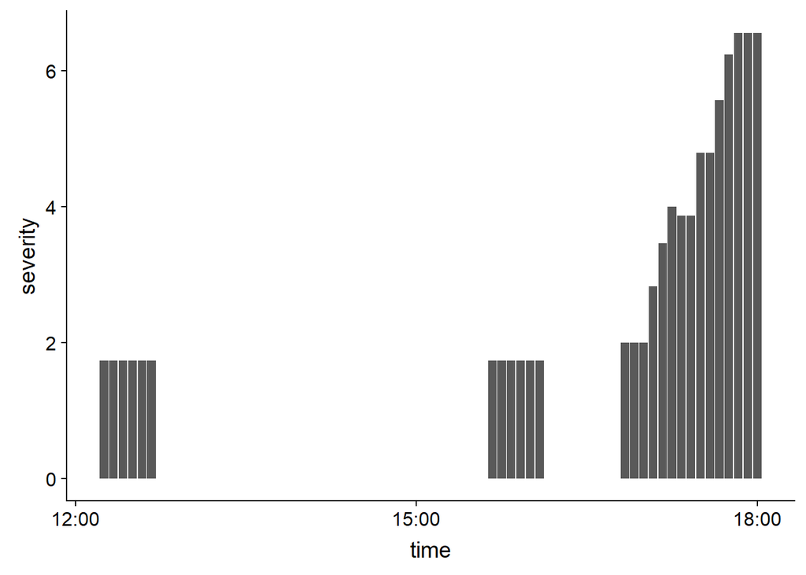

```r
severity <-
  jams_bbox %>%
  mutate(jam_rank = ifelse(subtype == "JAM_STAND_STILL_TRAFFIC", 4 , ifelse(subtype == "JAM_HEAVY_TRAFFIC", 3 , ifelse(is.na(subtype), 1, 2)))) %>%
  group_by(scrape_dt) %>%
  summarise(severity = sqrt(sum(jam_rank, na.rm = TRUE)))

ggplot(severity, aes(x = ymd_hms(scrape_dt), y = severity)) + geom_col() + labs(x = "time")
```

# 8 Waze aggregate over multiple events

1. The uuid of the major accident that I pick is :b97a5d7b-68d7-338f-b92a-a1dd8005fd4e. The accident ﬁrst appeared in the data on 2018-02-02 00:00:00 at 87.91959W, 41.91396N.

```r
accident <-waze %>% filter(uuid == "b97a5d7b-68d7-338f-b92a-a1dd8005fd4e")
print(accident)
```

```
## # A tibble: 20 x 17
##    country nTHumbsUp city  reportRating confidence reliability type  uuid
##    <chr>       <int> <chr>        <int>      <int>       <int> <chr> <chr>
##  1 US              0 <NA>             4          0           5 ACCI~ b97a~
##  2 US              0 <NA>             4          2          10 ACCI~ b97a~
##  3 US              0 <NA>             4          3          10 ACCI~ b97a~
##  4 US              0 <NA>             4          5          10 ACCI~ b97a~
##  5 US              0 <NA>             4          5          10 ACCI~ b97a~
##  6 US              0 <NA>             4          5          10 ACCI~ b97a~
##  7 US              0 <NA>             4          5          10 ACCI~ b97a~
##  8 US              0 <NA>             4          5          10 ACCI~ b97a~
##  9 US              0 <NA>             4          5          10 ACCI~ b97a~
## 10 US              0 <NA>             4          5          10 ACCI~ b97a~
## 11 US              0 <NA>             4          5          10 ACCI~ b97a~
## 12 US              0 <NA>             4          5          10 ACCI~ b97a~
## 13 US              0 <NA>             4          5          10 ACCI~ b97a~
## 14 US              0 <NA>             4          5          10 ACCI~ b97a~
## 15 US              0 <NA>             4          5          10 ACCI~ b97a~
## 16 US              0 <NA>             4          5          10 ACCI~ b97a~
## 17 US              0 <NA>             4          5          10 ACCI~ b97a~
## 18 US              0 <NA>             4          5          10 ACCI~ b97a~
## 19 US              0 <NA>             4          5          10 ACCI~ b97a~
## 20 US              0 <NA>             4          5          10 ACCI~ b97a~
## # ... with 9 more variables: roadType <int>, magvar <int>, subtype <chr>,
## #   street <chr>, location_x <dbl>, location_y <dbl>, pubMillis <dbl>,
## #   reportDescription <chr>, scrape_dt <dttm>
```

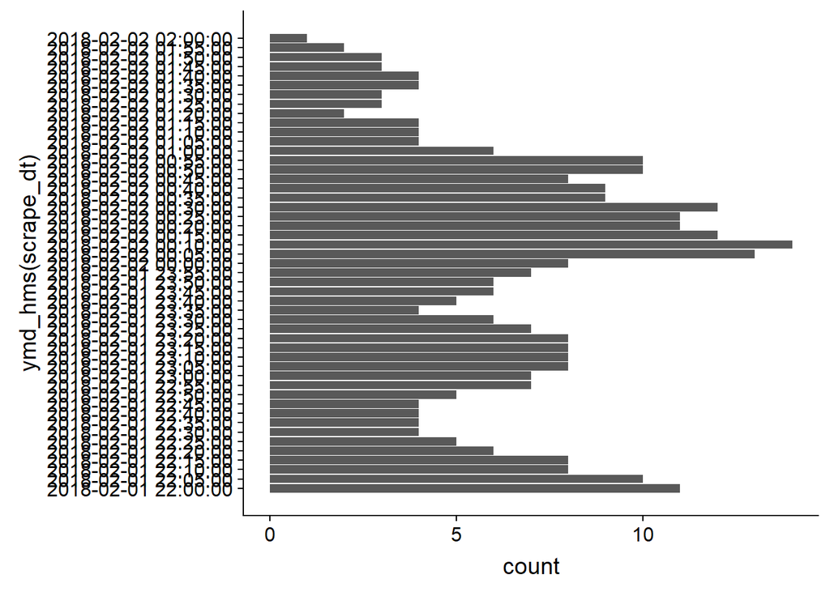

```r
vin_2h <-
  waze %>%
  filter(between(location_x, -87.91959 - 0.02, -87.91959 + 0.02) & between(location_y, 41.91396 - 0.02, 41.91396 + 0.02)) %>%
  filter(between(ymd_hms(scrape_dt), ymd_hms("2018-02-02 00:00:00") - dhours(2), ymd_hms("2018-02-02 00:00:00") + dhours(2)))

vin_2h_jam <- filter(vin_2h, type == "JAM")
vin_2h_jam %>% ggplot(aes(x = ymd_hms(scrape_dt))) + geom_bar() + scale_x_datetime(breaks = seq(ymd_hms("2018-02-02 00:00:00") - dhours(2), ymd_hms("2018-02-02 00:00:00") + dhours(2), dminutes(5))) + coord_flip()
```

```r
#function
return_n_alerts <- function(id, datetime, lon, lat){
  waze %>%
    filter(between(location_x, lon - 0.02, lon + 0.02) & between(location_y, lat - 0.02, lat + 0.02)) %>%
    filter(between(ymd_hms(scrape_dt), ymd_hms(datetime) - dhours(2), ymd_hms(datetime) + dhours(2))) %>%
    filter(type == "JAM") %>% group_by(scrape_dt) %>% summarise(n = n())
}

#test
return_n_alerts(id = "b97a5d7b-68d7-338f-b92a-a1dd8005fd4e", datetime = "2018-02-02 00:00:00", lon = -87.91959, lat = 41.91396)
```

```
## # A tibble: 49 x 2
##    scrape_dt               n
##    <dttm>              <int>
##  1 2018-02-01 22:00:00    11
##  2 2018-02-01 22:05:00    10
##  3 2018-02-01 22:10:00     8
##  4 2018-02-01 22:15:00     8
##  5 2018-02-01 22:20:00     6
##  6 2018-02-01 22:25:00     5
##  7 2018-02-01 22:30:00     4
##  8 2018-02-01 22:35:00     4
##  9 2018-02-01 22:40:00     4
## 10 2018-02-01 22:45:00     4
## # ... with 39 more rows
```

```r
nov20 <-
  waze %>%
  filter(between(ymd_hms(scrape_dt), ymd_hms("2017-11-20 00:00:00"), ymd_hms("2017-11-20 23:59:59"))) %>%
  filter(subtype == "ACCIDENT_MAJOR") %>%
  group_by(uuid) %>%
  summarise(datetime = first(scrape_dt), lon = first(location_x), lat = first(location_y))

#https://stackoverflow.com/questions/48833807/initialize-an-empty-tibble-with-column-names-and-0-rows
tblname <- c("uuid", "mean_alerts")
tbl <- as_tibble(data.frame(matrix(nrow = 0,ncol = 2)))
colnames(tbl) <- tblname

for (i in 1:nrow(nov20)) {
  acc <- nov20[i,]
  n_alerts <- return_n_alerts(id = acc[[1]], datetime = acc[[2]], lon = as.numeric(acc[[3]]), lat = as.numeric(acc[[4]]))
  tbl <- add_row(tbl, uuid = acc[[1]], mean_alerts = summarise(n_alerts, mean_alerts = mean(n))[[1]])
}
tbl
```

```
## # A tibble: 43 x 2
##    uuid                                 mean_alerts
##    <chr>                                      <dbl>
##  1 175b9823-c2f3-39a2-b9aa-49e6e5d9dc58        3.78
##  2 17e7eaa6-ee43-3d21-b817-cfaaee8e8f39        1.88
##  3 1cc6acea-750c-3b14-84cb-12ab3136e0cb        2.61
##  4 1e4ea830-4434-30c1-9814-714a8c29b5a7      NaN
##  5 23812108-16b3-3cc0-9838-7977e0d060a5        1
##  6 2c2a177e-d685-3fec-81cc-c4ea9a9cb630        2.08
##  7 2f2b388a-d73b-3cc3-a586-b0939e16fca6      NaN
##  8 325a2461-deaf-3268-8454-4718a6711640        5.21
##  9 3278eb43-8b79-3700-a00f-757c5c08e2d4        2.53
## 10 41dee701-39f3-3ec3-ab95-7d28b6136a21        3.08
## # ... with 33 more rows
```

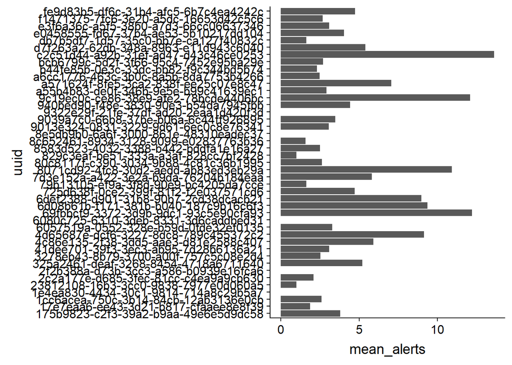

```r
ggplot(tbl, aes(x = uuid, y = mean_alerts)) + geom_col() + coord_flip()
```